# Discussion 13-Solution: Regression

Henry Mendoza Rivera, UW-Madison, Department of Statistics.

# Problem 1

A scientist is studying the effect of temperature on the yield of a certain product. The process is run 16 times, at the settings indicated in the data table.

| Observation | 1 | 2 | 3 | 4 | 5 | 6 | 7 | 8 | 9 | 10 | 11 | 12 | 13 | 14 | 15 | 16 |
| --- | --- | --- | --- | --- | --- | --- | --- | --- | --- | --- | --- | --- | --- | --- | --- | --- |
| Temp | 110 | 110 | 111 | 111 | 112 | 112 | 114 | 114 | 117 | 117 | 122 | 122 | 130 | 130 | 143 | 143 |
| Yield | 70.27 | 72.29 | 72.57 | 74.69 | 76.09 | 73.14 | 75.61 | 69.56 | 74.41 | 73.49 | 79.18 | 75.44 | 81.71 | 83.03 | 82.98 | 80.99 |

Build a linear regression model to predict the Yield based on the Temperature. Follow the steps given in Lecture.

# `Step 1:` Data Exploration: Scatterplot

```r
#enter data#
Temp<-c(110,110 ,111,   111 ,112,   112,    114,    114 ,117,   117,    122,    122,    130 ,130,143,   143)
Yield<-c(70.27,72.29,72.57,74.69,76.09,73.14,75.61,69.56,74.41,73.49,79.18,75.44,81.71,83.03,82.98,80.99)
```

## Numerical Summary

```r
summary(Temp)
```

```
##    Min. 1st Qu.  Median    Mean 3rd Qu.    Max.
##   110.0   111.8   115.5   119.9   124.0   143.0
```

```r
summary(Yield)
```

```
##    Min. 1st Qu.  Median    Mean 3rd Qu.    Max.
##   69.56   73.00   75.06   75.97   79.63   83.03
```

```r
sd(Temp)
```

```
## [1] 11.09279
```

```r
sd(Yield)
```

```
## [1] 4.357157
```

## Scatterplot

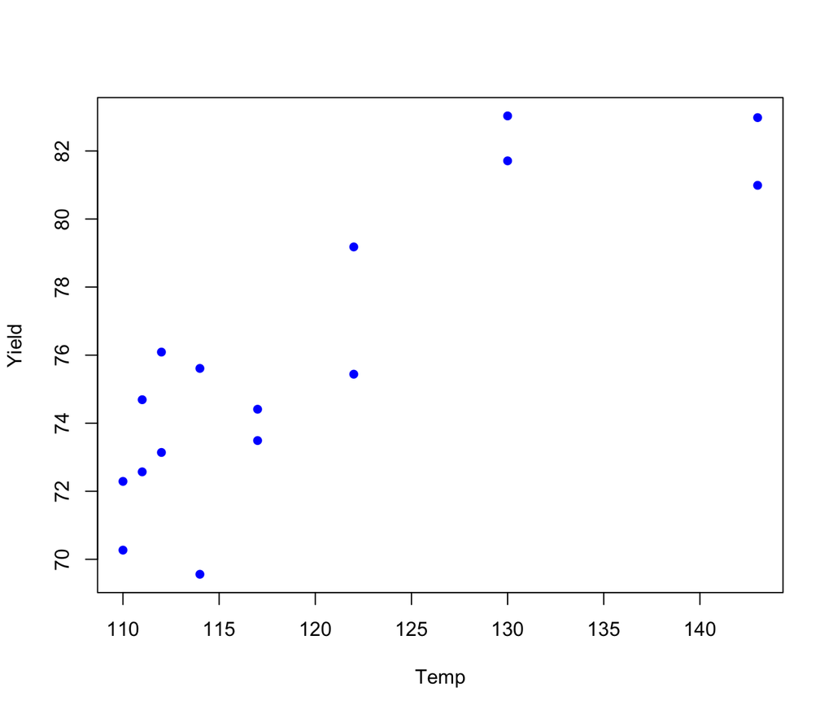

```r
plot(Yield ~ Temp, ylab = "Yield", xlab = "Temp",col="blue",pch=16)
```

# `Step 2:` Propose a model.

$$\bbox[#ffcc99,20px,border:10px ligth red]
{
\textrm{Yield }= \beta_{0} + \beta_{1}* \textrm{Temp} + \textrm{Random error}
}$$

In this formulation:

$\beta_{0}$ is the `intercept` (the value of Yield when the Temperature is zero) and

$\beta_{1}$ is the `slope` (the amount of change in Yield for a one degree change in Temperature).

For convenience, we will denote the yield $i$ by $y_{i}$, the temperature $i$ by $x_{i}$, and the random error by $\epsilon_{i}$, so that the model becomes:

$$\bbox[#ffcc99,20px,border:10px ligth red]
{
y_{i} = \beta_{0} + \beta_{1}x_{i} + \epsilon_{i}
}$$

## `Step 3:` Fit the model

### Parameters estimation

If $\hat{\beta}_{0}$ and $\hat{\beta}_{1}$ are our estimates, then the estimated (fitted) $y$ for any given $x$ is:

$$\bbox[#ffcc99,20px,border:10px ligth red]
{
\hat{y}_{i} = \hat{\beta}_{0} + \hat{\beta}_{1}x_{i}
}$$

For the Temperature and Yield data, these values work out to:

$$\bbox[#ffcc99,20px,border:10px ligth red]
{
\hat{\beta}_{1} = 0.3361 \;\textrm{ and }\;\hat{\beta}_{0} = 35.6740
}$$

```r
#model fit
mod <- lm(Yield ~ Temp)

mod
```

```
##
## Call:
## lm(formula = Yield ~ Temp)
##
## Coefficients:
## (Intercept)         Temp
##     35.6740       0.3361
```

The least squares estimate of the slope, $\hat{\beta}_{1} = 0.3361$, implies that the estimated mean Yield increases by $0.3361$ units for every 1-degree increase in Temperature.

Remember that the y-intercept is meaningfully interpretable only if x=0 is within the sampled range of the independent variable. Since x=0 is outside the range, $\hat{\beta}_{0}$ has no practical interpretation.

Interpretation

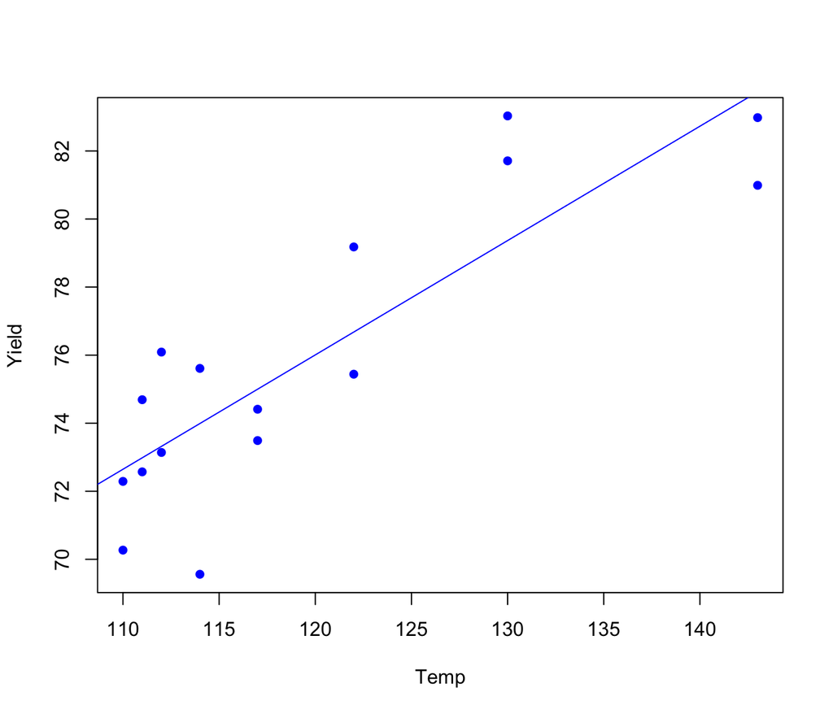

```r
plot(Yield ~ Temp, ylab = "Yield", xlab = "Temp",col="blue",pch=16)
abline(mod,col="blue")
```

## `Step 4:` Assess the quality of the fitted model

`Hypothesis:`

$$\bbox[#ffcc99,20px,border:10px ligth red]
{
H_{0}: \beta_{1} = 0\;\textrm{ vs}\;H_{A}: \beta_{1} \ne 0
}$$

`Assumptions:`

If we are willing to make some assumptions about the random error, we can perform a statistical test of these hypotheses. There are two ways to go about this, and they end up being equivalent. The `assumptions` we need for both are as follows:

1. The random error around the fitted line is normal
2. The variance around the fitted line is constant for all values of $x$.
3. The observations are independent.
4. The model is correct. (A straight line makes sense for the data.)

# Test statistics

$$\bbox[#ffcc99,20px,border:10px ligth red]
{
T = \frac{\hat{\beta}_{1} - 0}{\widehat{SE(\hat{\beta}_{1}})} \sim T_{n-2}
}$$

```r
summary(mod)
```

```
##
## Call:
## lm(formula = Yield ~ Temp)
##
## Residuals:
##     Min      1Q  Median      3Q     Max
## -4.4310 -1.3072 -0.3846  1.8658  3.6612
##
## Coefficients:
##             Estimate Std. Error t value Pr(>|t|)
## (Intercept) 35.67403    6.53800   5.456 8.46e-05 ***
## Temp         0.33611    0.05432   6.187 2.36e-05 ***
## ---
## Signif. codes:  0 '***' 0.001 '**' 0.01 '*' 0.05 '.' 0.1 ' ' 1
##
## Residual standard error: 2.334 on 14 degrees of freedom
## Multiple R-squared:  0.7322, Adjusted R-squared:  0.7131
## F-statistic: 38.28 on 1 and 14 DF,  p-value: 2.364e-05
```

The observed t is

$$\bbox[#ffcc99,20px,border:10px ligth red]
{
T =\frac{0.33611 - 0}{0.05432}\sim T_{14}=6.187
}$$

## Methods to take a decision

### `Method 1: Rejection region`

Since $\alpha = 0.05$. We put $\alpha/2$ in the left and right tails of the t distribution. The rejection region is defined by:

$$\bbox[#ffcc99,20px,border:10px ligth red]
{
\textrm{Reject}\;H_0:\beta_{1} = 0\;\textrm{if}\;T>t_{df_{Error},0.975}\;\;\textrm{or}\;\;T<t_{df_{Error},0.025}
}$$

Where $df_{Error}=16-2=14$, so that $t_{14,0.025}$ and $t_{14,0.975}$ are the critical values. We can compute them using R:

```r
t.1<-qt(0.025, df=14)
t.1
```

```
## [1] -2.144787
```

```r
t.2<-qt(0.975, df=14)
t.2
```

```
## [1] 2.144787
```

Since the tobs=$6.187$ do fall into the rejection region, we reject the null hypothesis. The slope is different from 0.

# `Method 2: P-value`

In R:

```r
p.value<-2*pt(q=6.187,df=14,lower.tail = FALSE)
p.value
```

```
## [1] 2.365612e-05
```

- Since the p-value is relatively small, $\textrm{p-value}=2.3656116\times 10^{-5}<0.05$. So we would reject at the $5\%$ level, and conclude that Temperature is related to Yield.

# `Step 5:` Evaluate the model assumptions

`Residuals`

```r
mod <- lm(Yield ~ Temp) # fit the model
mod$residuals # extract the residuals from the fitted model
```

```
##          1          2          3          4          5          6          7
## -2.3765055 -0.3565055 -0.4126189  1.7073811  2.7712678 -0.1787322  1.6190410
##          8          9         10         11         12         13         14
## -4.4309590 -0.5892991 -1.5092991  2.5001341 -1.2398659  2.3412271  3.6612271
##         15         16
## -0.7582466 -2.7482466
```

`Assumption 1`. The random variable error is normal distributed with mean $E(\varepsilon)=0$

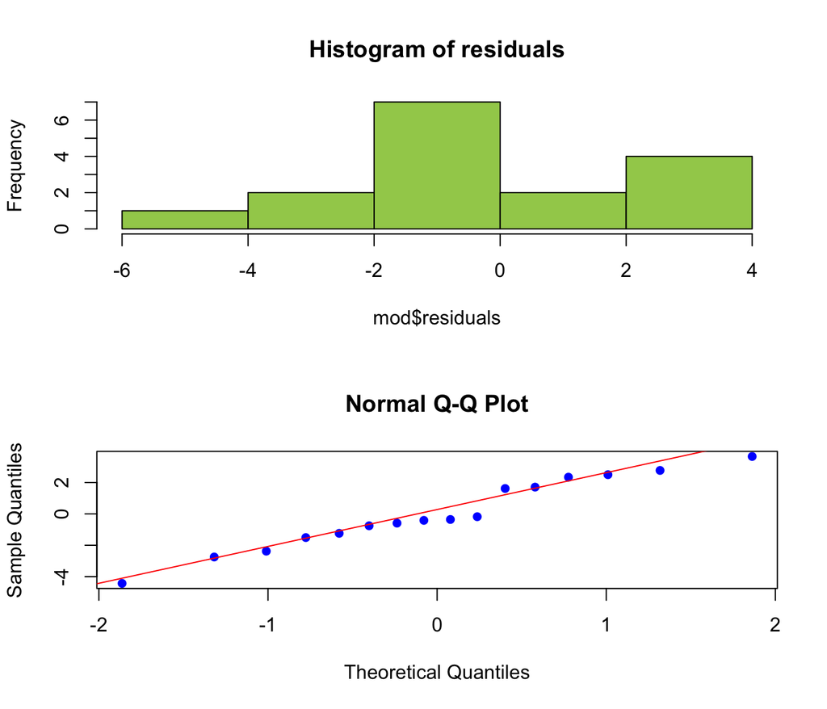

```r
par(mfrow=c(2,1))
hist(mod$residuals,col="darkolivegreen3",main = "Histogram of residuals")
qqnorm(mod$residuals,pch=16,col="blue")
qqline(mod$residuals,col="red")
```

- From the histogram and the qqplot, looks like the residual come from a Normal distribution with mean zero

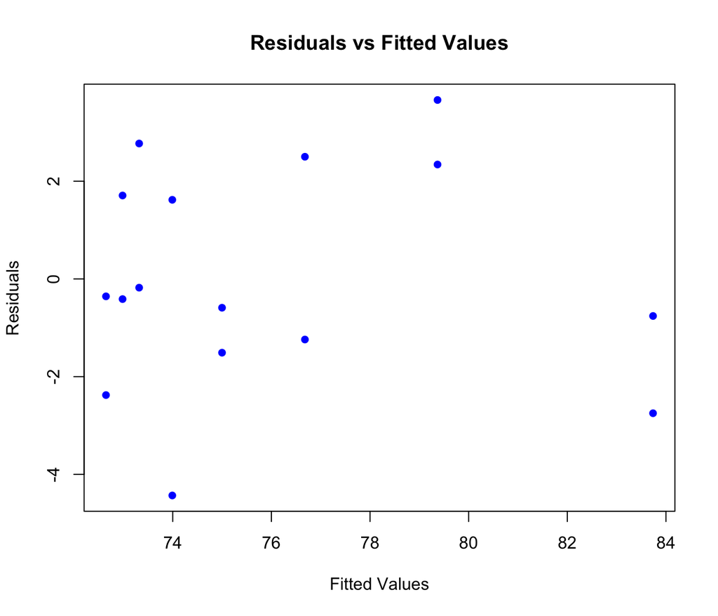

```r
plot(mod$residuals~mod$fitted.values,main = "Residuals vs Fitted Values",
     xlab="Fitted Values",ylab = "Residuals",col="blue",pch=16)
```

- We do not observe any pattern, the assumption of equality of variance of random variables errors is met.

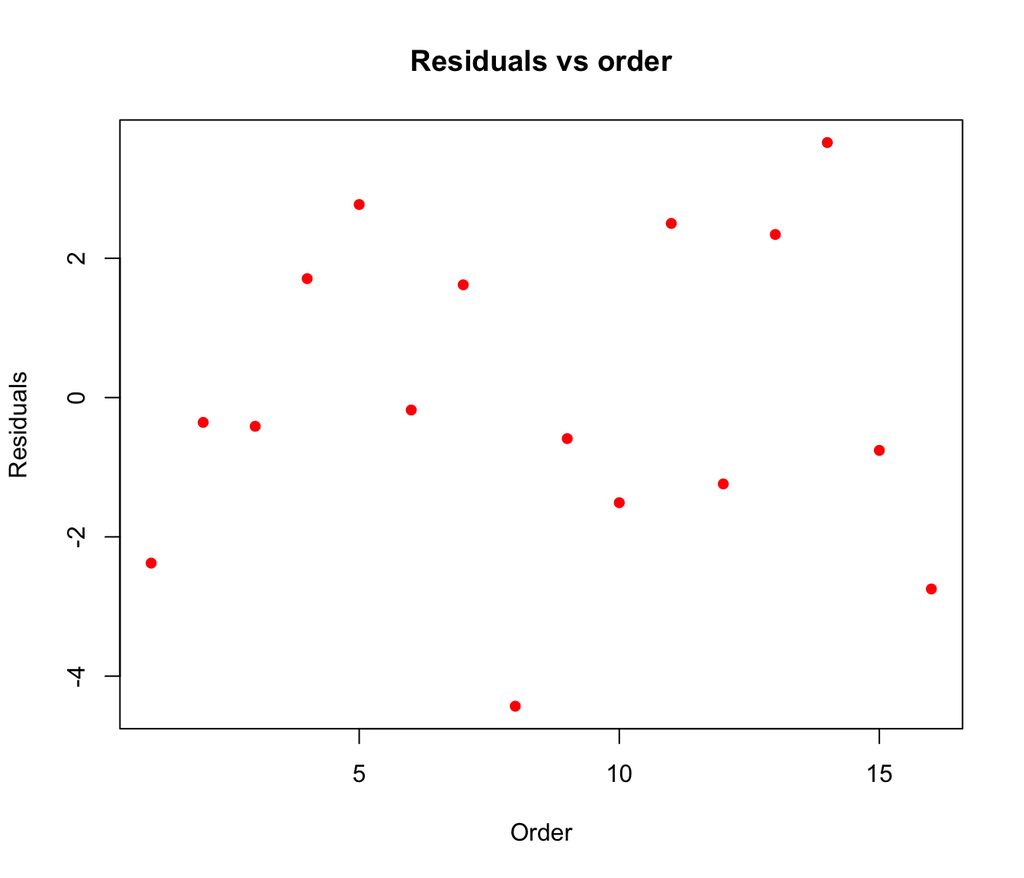

```r
x=seq(1:16)
y=mod$residuals
plot(x,y,main = "Residuals vs order",xlab="Order",ylab = "Residuals",col="red",pch=16)
```

- We do not observe any pattern, the assumption of independence of random variables errors is met.